# 68734_SLM_S1920_Report

Mateusz Dalba  
Index no.: 68734 | Wine dataset | Classification problem

1. Introduction

**Dataset description:**  
These data are the results of a chemical analysis of wines grown in the same region in Italy but derived from three different cultivars. The analysis determined the quantities of 13 constituents found in each of the three types of wines.

**Target variable:**  
wine cultivar/type (variable: **class**)  
**Features:**  
13 constituents/components such as **color intensity**, **% of Alcohol**, **Magnesium** etc.

**Problem description:**  
to classify (classification problem) the type of Wine (one of three avaliable), based on its attribues/features.

```python
import time
start_time = time.time()

#Import libraries
import pandas as pd
import numpy as np
import matplotlib.pyplot as plt
import seaborn as sns

from sklearn.model_selection import train_test_split
from sklearn.metrics import classification_report, confusion_matrix
from sklearn.metrics import roc_auc_score
from sklearn import preprocessing
from sklearn.preprocessing import StandardScaler
from sklearn.model_selection import GridSearchCV

import warnings
warnings.filterwarnings("ignore")

from sklearn.ensemble import RandomForestClassifier
from sklearn.linear_model import LogisticRegression
from sklearn.neighbors import KNeighborsClassifier

from sklearn.pipeline import Pipeline
```

```python
#Options
pd.set_option('display.max_columns', 100)
sns.set_style('whitegrid')
```

```python
#Read data
data = pd.read_csv('https://archive.ics.uci.edu/ml/machine-learning-databases/wine/wine.data',header=None)
```

```python
#Variables names
columns = ['class','Alcohol','Malic acid','Ash','Alcalinity of ash','Magnesium','Total phenols','Flavanoids','Nonflavanoid phenols','Proanthocyanins','Color intensity','Hue','OD280/OD315 of diluted wines','Proline']
```

```python
#Loading variables to dataset
data.columns = columns
```

```python
data.head(10)
```

|  | class | Alcohol | Malic acid | Ash | Alcalinity of ash | Magnesium | Total phenols | Flavanoids | Nonflavanoid phenols | Proanthocyanins | Color intensity | Hue | OD280/OD315 of diluted wines | Proline |
| --- | --- | --- | --- | --- | --- | --- | --- | --- | --- | --- | --- | --- | --- | --- |
| 0 | 1 | 14.23 | 1.71 | 2.43 | 15.6 | 127 | 2.80 | 3.06 | 0.28 | 2.29 | 5.64 | 1.04 | 3.92 | 1065 |
| 1 | 1 | 13.20 | 1.78 | 2.14 | 11.2 | 100 | 2.65 | 2.76 | 0.26 | 1.28 | 4.38 | 1.05 | 3.40 | 1050 |
| 2 | 1 | 13.16 | 2.36 | 2.67 | 18.6 | 101 | 2.80 | 3.24 | 0.30 | 2.81 | 5.68 | 1.03 | 3.17 | 1185 |
| 3 | 1 | 14.37 | 1.95 | 2.50 | 16.8 | 113 | 3.85 | 3.49 | 0.24 | 2.18 | 7.80 | 0.86 | 3.45 | 1480 |
| 4 | 1 | 13.24 | 2.59 | 2.87 | 21.0 | 118 | 2.80 | 2.69 | 0.39 | 1.82 | 4.32 | 1.04 | 2.93 | 735 |
| 5 | 1 | 14.20 | 1.76 | 2.45 | 15.2 | 112 | 3.27 | 3.39 | 0.34 | 1.97 | 6.75 | 1.05 | 2.85 | 1450 |
| 6 | 1 | 14.39 | 1.87 | 2.45 | 14.6 | 96 | 2.50 | 2.52 | 0.30 | 1.98 | 5.25 | 1.02 | 3.58 | 1290 |
| 7 | 1 | 14.06 | 2.15 | 2.61 | 17.6 | 121 | 2.60 | 2.51 | 0.31 | 1.25 | 5.05 | 1.06 | 3.58 | 1295 |
| 8 | 1 | 14.83 | 1.64 | 2.17 | 14.0 | 97 | 2.80 | 2.98 | 0.29 | 1.98 | 5.20 | 1.08 | 2.85 | 1045 |
| 9 | 1 | 13.86 | 1.35 | 2.27 | 16.0 | 98 | 2.98 | 3.15 | 0.22 | 1.85 | 7.22 | 1.01 | 3.55 | 1045 |

```python
#Basic info about Dataset
data.info()
```

```
<class 'pandas.core.frame.DataFrame'>
RangeIndex: 178 entries, 0 to 177
Data columns (total 14 columns):
 #   Column                        Non-Null Count  Dtype
---  ------                        --------------  -----
 0   class                         178 non-null    int64
 1   Alcohol                       178 non-null    float64
 2   Malic acid                    178 non-null    float64
 3   Ash                           178 non-null    float64
 4   Alcalinity of ash             178 non-null    float64
 5   Magnesium                     178 non-null    int64
 6   Total phenols                 178 non-null    float64
 7   Flavanoids                    178 non-null    float64
 8   Nonflavanoid phenols          178 non-null    float64
 9   Proanthocyanins               178 non-null    float64
 10  Color intensity               178 non-null    float64
 11  Hue                           178 non-null    float64
 12  OD280/OD315 of diluted wines  178 non-null    float64
 13  Proline                       178 non-null    int64
dtypes: float64(11), int64(3)
memory usage: 19.6 KB
```

```python
#All data is numeric, 13 variables, 178 observations, size of 19.6 KB, all variables not null
```

```python
#No null data
data.isnull().any().any()
```

```
False
```

```python
#No na data
data.isna().any().any()
```

```
False
```

```python
#No zeros in data
(data==0).any().any()
```

```
False
```

```python
#No negative data
(data<0).any().any()
```

```
False
```

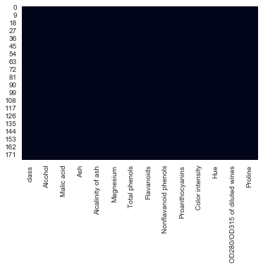

```python
#Visualize null data
sns.heatmap(data.isnull(),cbar=False)
```

```python
#Name of columns - need to create histograms
data.columns
```

```
Index(['class', 'Alcohol', 'Malic acid', 'Ash', 'Alcalinity of ash',
       'Magnesium', 'Total phenols', 'Flavanoids', 'Nonflavanoid phenols',
       'Proanthocyanins', 'Color intensity', 'Hue',
       'OD280/OD315 of diluted wines', 'Proline'],
      dtype='object')
```

```python
# Histograms for each variable
def create_hists(kde=True):
    f, axes = plt.subplots(2, 7,figsize=(15,10), sharex=False)
    sns.distplot(data["class"] , color="skyblue", ax=axes[0, 0],kde=False)
    sns.distplot(data["Alcohol"] , color="olive", ax=axes[0, 1],kde=kde)
    sns.distplot(data["Malic acid"] , color="gold", ax=axes[0, 2],kde=kde)
    sns.distplot(data["Ash"] , color="teal", ax=axes[0, 3],kde=kde)
    sns.distplot(data["Alcalinity of ash"] , color="plum", ax=axes[0, 4],kde=kde)
    sns.distplot(data["Magnesium"] , color="tomato", ax=axes[0, 5],kde=kde)
    sns.distplot(data["Total phenols"] , color="steelblue", ax=axes[0, 6],kde=kde)
    sns.distplot(data["Flavanoids"] , color="cyan", ax=axes[1, 0],kde=kde)
    sns.distplot(data["Nonflavanoid phenols"] , color="lightgreen", ax=axes[1, 1],kde=kde)
    sns.distplot(data["Proanthocyanins"] , color="indigo", ax=axes[1, 2],kde=kde)
    sns.distplot(data["Color intensity"] , color="salmon", ax=axes[1, 3],kde=kde)
    sns.distplot(data["Hue"] , color="red", ax=axes[1, 4],kde=kde)
    sns.distplot(data["OD280/OD315 of diluted wines"] , color="purple", ax=axes[1, 5],kde=kde)
    sns.distplot(data["Proline"] , color="grey", ax=axes[1, 6],kde=kde)
    plt.show()
    plt.tight_layout()
```

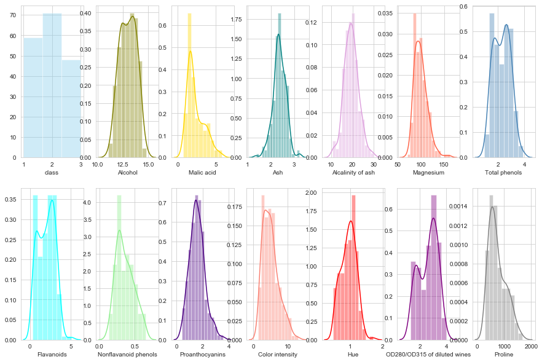

```python
create_hists(kde=True)
```

```python
#I am not a chemist but still all variables look quite "normal"/correct
```

```python
#Descriptive statistics
data.describe()
```

|  | class | Alcohol | Malic acid | Ash | Alcalinity of ash | Magnesium | Total phenols | Flavanoids | Nonflavanoid phenols | Proanthocyanins | Color intensity | Hue | OD280/OD315 of diluted wines | Proline |
| --- | --- | --- | --- | --- | --- | --- | --- | --- | --- | --- | --- | --- | --- | --- |
| count | 178.000000 | 178.000000 | 178.000000 | 178.000000 | 178.000000 | 178.000000 | 178.000000 | 178.000000 | 178.000000 | 178.000000 | 178.000000 | 178.000000 | 178.000000 | 178.000000 |
| mean | 1.938202 | 13.000618 | 2.336348 | 2.366517 | 19.494944 | 99.741573 | 2.295112 | 2.029270 | 0.361854 | 1.590899 | 5.058090 | 0.957449 | 2.611685 | 746.893258 |
| std | 0.775035 | 0.811827 | 1.117146 | 0.274344 | 3.339564 | 14.282484 | 0.625851 | 0.998859 | 0.124453 | 0.572359 | 2.318286 | 0.228572 | 0.709990 | 314.907474 |
| min | 1.000000 | 11.030000 | 0.740000 | 1.360000 | 10.600000 | 70.000000 | 0.980000 | 0.340000 | 0.130000 | 0.410000 | 1.280000 | 0.480000 | 1.270000 | 278.000000 |
| 25% | 1.000000 | 12.362500 | 1.602500 | 2.210000 | 17.200000 | 88.000000 | 1.742500 | 1.205000 | 0.270000 | 1.250000 | 3.220000 | 0.782500 | 1.937500 | 500.500000 |
| 50% | 2.000000 | 13.050000 | 1.865000 | 2.360000 | 19.500000 | 98.000000 | 2.355000 | 2.135000 | 0.340000 | 1.555000 | 4.690000 | 0.965000 | 2.780000 | 673.500000 |
| 75% | 3.000000 | 13.677500 | 3.082500 | 2.557500 | 21.500000 | 107.000000 | 2.800000 | 2.875000 | 0.437500 | 1.950000 | 6.200000 | 1.120000 | 3.170000 | 985.000000 |
| max | 3.000000 | 14.830000 | 5.800000 | 3.230000 | 30.000000 | 162.000000 | 3.880000 | 5.080000 | 0.660000 | 3.580000 | 13.000000 | 1.710000 | 4.000000 | 1680.000000 |

```python
#No outliers in the data
```

```
2    71
1    59
3    48
Name: class, dtype: int64
```

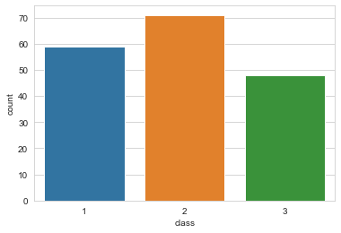

```python
#Target variable
print(data['class'].value_counts())


sns.countplot(data['class'])
```

```python
data['class'].value_counts()
```

```
2    71
1    59
3    48
Name: class, dtype: int64
```

```python
#Target variable is balanced
```

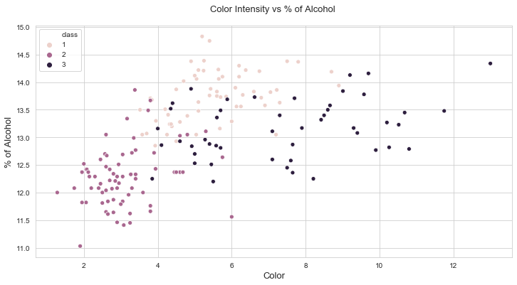

```python
plt.figure(figsize=(12,6))
sns.scatterplot(data=data,x='Color intensity',y='Alcohol',hue='class',legend='full')
plt.title('Color Intensity vs % of Alcohol \n' ,fontsize=13)
plt.xlabel('Color',fontsize=13)
plt.ylabel('% of Alcohol',fontsize=13)
plt.show()
```

It is clearly visable that higher Color Intensity means more % of Alcohol.  
Darker alcohol = stronger alcohol.

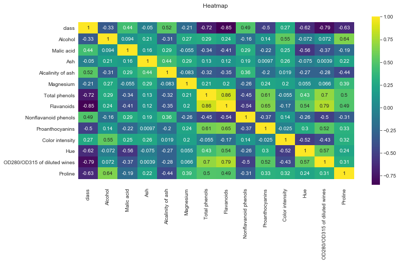

```python
plt.figure(figsize=(12,6))
sns.heatmap(data.corr(),annot=True,cmap='viridis')
plt.title('Heatmap \n')

#Adding b,t variables to get rid of cutted edges of heatmap
b, t = plt.ylim()
b += 0.5
t -= 0.5
plt.ylim(b, t)

plt.show()
```

Strongly correlated variables with target var: Flavanoids -0,85 ; Total phenols -0.72 ; 0D280/OD315 of diluted wines -0.79

**EDA insights summary:**  
Provided dataset is clean. There is no missing data, null or nans. All the values are > 0.  
Looking at histograms and .describe() method there are no outliers/anomalies in the dataset, however  
to ensure that some knowledge about Wines / Chemistry is needed here.  
Target variable and other variables are balanced  
All variables are numeric.  
Data needs to be standarized.  
Strongly correlated features with target variable (3 variables) will be dropped to further analysis.

```python
######
###Modeling part####
######
```

```python
y = data[['class']]
```

```python
#Dropping highly correlated features to target variable
X = data.drop(labels=['class','Flavanoids','Total phenols','OD280/OD315 of diluted wines'],axis=1)
```

```python
#Train : Test -> 60 : 40
X_train, X_test, y_train, y_test = train_test_split(X, y, test_size=0.4, random_state=101)
```

```python
#Scaling data
scaler = StandardScaler()
X_train = scaler.fit_transform(X_train)
X_test = scaler.transform(X_test)
```

```python
#Target variable is multiclass format
y = preprocessing.label_binarize(y, classes=[1, 2, 3])
```

```python
#3 models selected: KNN , Logistic Regression, Random Forest
logisticRegr = LogisticRegression()
knn = KNeighborsClassifier()
rfc = RandomForestClassifier()
```

```python
#Fitting Logistic Regression with default parameters
logisticRegr.fit(X_train, y_train)
```

```
LogisticRegression(C=1.0, class_weight=None, dual=False, fit_intercept=True,
                   intercept_scaling=1, l1_ratio=None, max_iter=100,
                   multi_class='auto', n_jobs=None, penalty='l2',
                   random_state=None, solver='lbfgs', tol=0.0001, verbose=0,
                   warm_start=False)
```

```python
#Fitting KNN with default parameters
knn.fit(X_train,y_train)
```

```
KNeighborsClassifier(algorithm='auto', leaf_size=30, metric='minkowski',
                     metric_params=None, n_jobs=None, n_neighbors=5, p=2,
                     weights='uniform')
```

```python
#Fitting Random Forest with default parameters
rfc.fit(X_train,y_train)
```

```
RandomForestClassifier(bootstrap=True, ccp_alpha=0.0, class_weight=None,
                       criterion='gini', max_depth=None, max_features='auto',
                       max_leaf_nodes=None, max_samples=None,
                       min_impurity_decrease=0.0, min_impurity_split=None,
                       min_samples_leaf=1, min_samples_split=2,
                       min_weight_fraction_leaf=0.0, n_estimators=100,
                       n_jobs=None, oob_score=False, random_state=None,
                       verbose=0, warm_start=False)
```

```python
#Logistic Regression predictions
logisticRegr_predictions = logisticRegr.predict(X_test)
```

```python
#KNN predictions
knn_predictions = knn.predict(X_test)
```

```python
#Random Forest predictions
rfc_predictions = rfc.predict(X_test)
```

```python
print('Classification report for Logistic Regression: \n' )
print(classification_report(y_test, logisticRegr_predictions))
```

```
Classification report for Logistic Regression:

              precision    recall  f1-score   support

           1       1.00      0.96      0.98        25
           2       0.96      0.96      0.96        27
           3       0.95      1.00      0.98        20

    accuracy                           0.97        72
   macro avg       0.97      0.97      0.97        72
weighted avg       0.97      0.97      0.97        72
```